# Bent Winter 2008

R. G. Cronce

12/19/2019

# Bent Brain Ticklers, Winter 2008

## Problem 1

```
Ann, Beth, and Clara have been
challenged to find a solution to the
following cryptic:

FOUR is a perfect square;
FIVE is a Fibonacci number; &
SIX is a semi-prime (product of
two primes).

Each girl found a different solution,
and the values of FOUR, FIVE, and
SIX in Clara's solution were not used
in Ann's or Beth's answer. What was
Clara's solution? The usual rules
apply. No leading zeroes, and each
letter represents a different digit.

-- Richard England in New Scientist
```

Solution: solved in the cryptic arithmetic notebook

```
  FOUR is a perfect square
  FIVE is a Fibonacci number
  SIX is a semi-prime (product of two prime numbers)

  Ann, Beth, and Clara found a different solution

  FOUR, FIVE, and SIX in Clara's solution not in Ann's or Beth's.

  What is Clara's solution?


1. There are only two 4 digit Fibonacci numbers with 4 distinct digits:

    1597 and 2584

2. There are 36 4 digit perfect squares with 4 distinct digits.  The
   only ones that start with the same digit as the Fibonacci numbers
   are of the form 1*** or 2***.  Furthermore, the perfect squares
   can not have any duplicate digits with the Fibonacci numbers other
   than the leading digit.  This limits the solution sets to:

    FOUR   FIVE
    -------------------------------
    1597   1024
    2584   2601 2916

3. Three digit semi-primes: there are lots of them (265).  The middle
   digit must match the second digit of FIVE and the other digits
   can not occur in FOUR or FIVE.  This reduces the solution set
   to the following:


    FOUR   FIVE     SIX
    -------------------
    1597   1024     803  <-- Clara's solution
    2584   2601     763
    2584   2916     793

    Clara's solution must be the unique row (the first one).

    Can't say which one is Ann or Beth.
```

## Problem 2

```
Consider a regular pentagram
(five-pointed star) with a circumscribing
circle of unit radius. Fold
the five points of the star so that
their tips meet in a point to form a
pyramid with a regular pentagon as
its base. What is the volume of this
pyramid?

-- Slicing Pizzas, Racing Turtles,
and Further Adventures in Applied
Mathematics by Robert B. Banks
```

Solution:

```
Let's look at a picture first.
We will draw the circle and the star and then
figure things out:
```

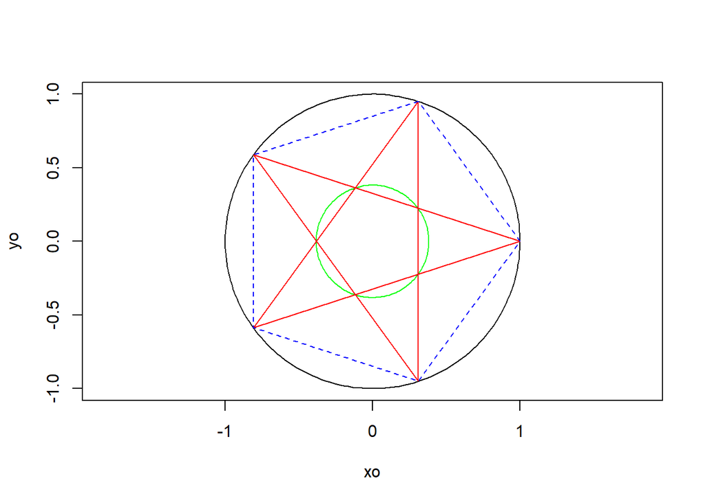

```
We need to work out the size of the internal pentagon and the
length of the sides of the "points" of the star.  Once we have
that we should be able to find the volume.

A pentagon divides the circle into 5 parts so each angle is 360/5 = 72 degrees.
The internal angle (between sides) of the pentagon are just 180-72=108 degrees.

The sides of the outside pentagon connect points on the unit circle so we
can calculate the length of a side as:

    L = 2*sin(36 degrees) = 1.175571

The isosceles triangle with this as a base has two 36 degree base angles with
a height of h/(L/2) = tan(36) so

    h = (L/2)*tan(36) = sin(36)*tan(36)

So, the distance from the center of the circle to the point(s) of the internal
pentagon are:

    r2 = 1*cos(36)-sin(36)*tan(36)

Now that we know the radius of the interior circle we can calculate the length
of each side of the smaller pentagon.  This is just:

    L2 = 2*r2*sin(36)

The points of the stars have base angles of 180-108=72 degrees.  The length of
a side of the point is then:

    (L2/2)/d = cos(72) --> d = (L2/2)/cos(72)

The height of each star point is:

    hpoint = d*sin(72)

The distance from the center of the circle to the middle of a side of the small
pentagon is:

    d2 = r2*cos(36) = (1-sin(36)*tan(36))*cos(36)

Based on d,hpoint we can calculate the height of the 5-sided pyramid when the
points are flipped up:

    hp = sqrt(hpoint^2 - d2^2)

So - at this point we know the base dimensions and the height of the pyramid.
This is sufficient to calculate the volume.
```

```r
r=1
theta=seq(0,2*pi,length=200)
xo=r*cos(theta)
yo=r*sin(theta)
r2=0.382
xi=r2*cos(theta)
yi=r2*sin(theta)
plot(xo,yo,type='n',asp=1)
polygon(xo,yo)
polygon(xi,yi,border='green')
dtheta=2*pi/5
theta=seq(5)*dtheta
x=r*cos(theta)
y=r*sin(theta)
#
lines(x[c(1,3)],y[c(1,3)],col='red')
lines(x[c(1,4)],y[c(1,4)],col='red')
#
lines(x[c(2,4)],y[c(2,4)],col='red')
lines(x[c(2,5)],y[c(2,5)],col='red')
#
lines(x[c(3,5)],y[c(3,5)],col='red')

polygon(x,y,lty='dashed',border='blue')
```

```r
theta=36*pi/180
L=2*sin(theta)
h=(L/2)*tan(theta)
r2=1*cos(theta)-sin(theta)*tan(theta)
L2=2*r2*sin(theta)
d=(L2/2)/cos(2*theta)
hpoint=d*sin(2*theta)
d2=r2*cos(theta)
hp=sqrt(hpoint^2-d2^2)
# Area of the central pentagon
area=1/2*L2*d2*5
# Volume of the pyramid
V=5*L2*d2*hp/6


print(paste0("Side of outside pentagon = ",L,collapse=""))
```

```
## [1] "Side of outside pentagon = 1.17557050458495"
```

```r
print(paste0("Height of outer triangle = ",h,collapse=""))
```

```
## [1] "Height of outer triangle = 0.427050983124842"
```

```r
print(paste0("Radius of inside circle  = ",r2,collapse=""))
```

```
## [1] "Radius of inside circle  = 0.381966011250105"
```

```r
print(paste0("Side of inside  pentagon = ",L2,collapse=""))
```

```
## [1] "Side of inside  pentagon = 0.449027976579585"
```

```r
print(paste0("Height of star point     = ",hpoint,collapse=""))
```

```
## [1] "Height of star point     = 0.690983005625053"
```

```r
print(paste0("Height = ",hp,collapse=""))
```

```
## [1] "Height = 0.618033988749895"
```

```r
print(paste0("Area of base pentagon    = ",area,collapse=""))
```

```
## [1] "Area of base pentagon    = 0.34689318928222"
```

```r
print(paste0("Volume of pyramid        = ",V,collapse=""))
```

```
## [1] "Volume of pyramid        = 0.0714639271474208"
```

Might be able to calculate this another way. Consider a circle of radius=r that circumscribes a pentagon. The ratio of the pentagon area to the circle area is:

```
area_p = 1/2*L*d*5
   d=cos(theta)
   L/2=sin(theta)
   theta = pi/5

area_p = sin(theta)*cos(theta)*5
       = 2.377641

area_c = pi*r^2 = pi

ratio = area_p/area_c = 0.7568267
```

At each slice the area ratio holds so if we calculate the volume of a cone of height hp the volume of the pentagonal pyramid should be this ratio times that volume. For the central circle/pentagon given above:

```
V_Cone = 1/3*pi*r2**2*hp
       = 1/3*pi*(0.38196601125010^2)*0.618033988749895
       = 0.09442574
```

so:

```
V_pyramid = V_cone * 0.7568267
          = 0.07146392
```

Which is the same as above.

## Problem 3

```
Find the positive root of the following
equation:

    (x + 9)**(1/3) - (x - 9)**(1/3) = 3.

Express your answer exactly in
terms of surds.

-- Mathematics Teacher
```

Solution:

```
x = 4*sqrt(5) is the positive root.

Visualize this for some range of x to get an idea of what
is going on:
```

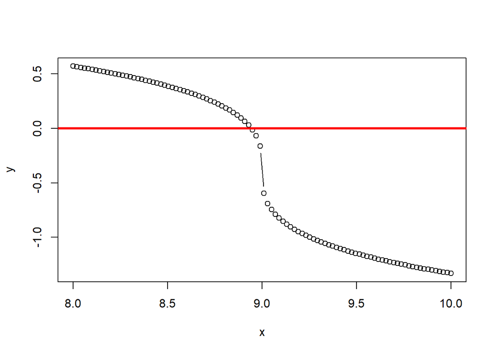

```r
x=seq(8,10,length=100)
y=rep(0,length(x))
for (i in seq_along(x)) {
    if (x[i]<9) {
        y[i]=(x[i]+9)^(1/3)+(9-x[i])^(1/3) - 3
    } else {
        y[i]=(x[i]+9)^(1/3)-(x[i]-9)^(1/3) - 3
    }
}
plot(x,y,type='b')
abline(h=0,col='red',lwd=3)
```

So - we expect a solution somewhere near x=9. This is confusing due to the sign issue for cube root of (x-9) for x<9. We can eliminate this if we rearrange the equation and cube it:

```
(x+9)^(1/3) - (x-9)^(1/3) = 3

(x+9)^(1/3) - 3 = (x-9)^(1/3)

((x+9)^(1/3) - 3)^3 = x-9

(x+9) - 9 * (x+9)^(2/3) + 27 * (x+9)^(1/3) - 27 = x-9

(18-27) - 9*(x+9)^(2/3) + 27*(x+9)^(1/3) = 0

-9 - 9*(x+9)^(2/3) + 27*(x+9)^(1/3) = 0

1 + (x+9)^(2/3) - 3*(x+9)^(1/3) = 0

Let u = (x+9)^(1/3) then x = u^3 - 9

u**2 - 3*u + 1 = 0

u = (3 +/- sqrt(9-4))/2

Choosing the positive root:

u = (3+sqrt(5))/2

So

x = u^3 - 9 = ((3+sqrt(5))/2)^3 - 9
  = 4*sqrt(5)
  ~ 8.944272
```

## Problem 4

```
In a garden is a circular pond
with a horizontal bottom and vertical
sides. The owner of the garden
decides to erect a statue in the
middle of the pond. In preparation,
three identical cubical (solid and
impermeable) concrete blocks are
placed side by side in the pond to
form a base for the statue. When the
first block is placed in the pond, the
water level rises three inches. When
the second block is placed, the water
level rises another four inches. And,
when the third block is added, the
water level again rises four inches.
What is the length of the edges of
the blocks?

-- Almost Impossible Brain Bafflers
by Tim Sole and Rod Marshall
```

Solution:

```
When the cubes are placed in the water they will
raise the water level based on their displacement.
If the cubes were fully submerged then adding each
cube would raise the water level by the same amount.
Since this does not occur, we know the first cube
is not fully submerged.  Whether or not the second
cube is full submerged is difficult to know.  We will
assume so and look for contradictions.

A = cross sectional area of pond
h0 = initial water height

V = A*h0 -> volume of water in pond

Add first block (partially submerged):

    A*(h0+3)-S*S*(h0+3) = A*h0   [1]

Add second block (two blocks fully submerged):

    A*(h0+7)-2*S*S*S = A*h0   [2]

Add third block (three blocks fully submerged):

    A*(h0+11)-3*S*S*S = A*h0   [3]

From equation [2]: 7*A-2*S*S*S = 0  --> A = (2/7)*S*S*S
From equation [3]: 11*A-3*S*S*S = 0 --> A = (3/11)*S*S*S

CONTRADICTION!!!

Second scenario:

Add first block (partially submerged):

    A*(h0+3)-S*S*(h0+3) = A*h0   [1]

Add second block (partially submerged):

    A*(h0+7)-2*S*S*(h0+7) = A*h0   [2]

Add third block (three blocks fully submerged):

    A*(h0+11)-3*S*S*S = A*h0   [3]

From equation [1]: 3*A-S*S*(h0+3) = 0
From equation [2]: 7*A-2*S*S*(h0+7) = 0

Combining: 1/3*(h0+3) = 2/7*(h0+7)
   7*(h0+3) = 6*(h0+7)
   h0 = 21 in

Substituting into equations [1-3]:

    [1] 3*A - 24*S*S = 0  -> A = 8*S*S
    [2] 7*A - 56*S*S = 0  -> useless
    [3] 11*A - 3*S*S*S = 0 -> 88*S*S - 3*S*S*S = 0

    S = 88/3 in
      = 29.3333 in

    A = 8*S*S = 6883.556 in^2
      = 47.802 ft^2
```

## Problem 5

```
Using a standard set of 28 dominos,
Carl laid out in a row, in typical
domino style with ends matching,
e.g., 6-3, 3-5, 5-5, 5-1. He started with
0-0 and then added dominos, building
on either end of the string, so
that the total number of pips in the
row equaled 1, then 4, then 9, working
through each perfect square and
continuing as far as possible. His row
could not have been shorter at any
stage. When he reached the highest
square possible, he was left with five
unused dominos, four of which were
doubles. What were those five
dominos? List the complete order of the domino row of
your solution.

-- Adrian Somerfield in New Scientist
```

```
Don't care
```

## Bonus

```
In the game of Thirty Five, each player is dealt
a hand of nine cards from a standard deck of 52 cards. To
win a pot, one must be able to select cards in a single suit
to obtain a score of 35, where face cards count 10, aces
count 1, and all other cards have their designated value.
What is the probability of getting a hand that can win the
pot?

-- Howard G. McIlvried III, PA Gamma'53
```

Solution: try Monte-Carlo

```r
library(gtools)

is_winner = function(h) {
    for (r in 4:length(h)) {
        a=combinations(length(h),r,h,set=F)
        if (any(apply(a,1,sum)==35)) {
            return(TRUE)
        }
    }
    return(FALSE)
}

pipval=c(1,2,3,4,5,6,7,8,9,10,10,10,10)
cards=0:51

ntrials=1000000

set.seed(2020)
win=0
for (trial in 1:ntrials) {
    s=sample(cards,9)
    winner=0
    for (i in 0:3) {
        h=pipval[s[trunc(s/13)==i]%%13+1]
        if (sum(h)>=35) {
            if (is_winner(h)) {
                winner=1
            }
        }
    }
    win=win+winner
}
print(win)
```

```
## [1] 39265
```

```r
print(win/ntrials)
```

```
## [1] 0.039265
```

```
Pr         Trials    Seed
0.038966   1e6       42
0.039335   1e6       123
0.039265   1e6       2020
```

According to the closed form counting in the Bent:

```
Pr = 0.0391

(143784024/3679075400)
```

After looking at the solution I don’t think counting is worth it. Random sampling is good enough for me.

## Double Bonus

```
In 2006, the age of a famous composer
would be, if he were still alive, equal to 10 times 10 less
than his age when he died. His age at death equals 2006
minus the reverse of the year he died. Who is this composer?

-- Dr. Aziz S. Inan, CA Epsilon'78
```

Solution:

```
b = year of birth
d = year of death = wxyz
a = age at death

(2006-b) = 10*(d-b-10)

(d-b) = 2006-zyxw

Solve first equation for b: 2006-10*d+100 = -9*b -> b = (10*d-2106)/9
substituting in the second equation:

(d-(10*d-2106)/9) = 2006-zyxw

(9*d-10*d+2106)/9 = 2006-zyxw

2106-d = 9*(2006-zyxw)

2106-wxyz = 9*(2006-zyxw)

By exhaustive elimination:

d = wxyz = 1791 (year of death)
b = 1756
age at death = 35

Famous Composer = Mozart
```